# ggplot practice

```r
library(ggplot2) # Load ggplot
ht_data <- read.csv("~/GitHub/REM504-DataScience/Practice_Datasets/height_compare_sims.csv", header = TRUE, stringsAsFactors = FALSE)
View(ht_data)
```

This dataset is from a set of simulations I ran comparing two different methods for measuring vegetation height. We want to look at how well the two methods do at estimating the true average vegetation height in two simulated environments (Dense with small plants, Sparse with big plants).

## ggplot basics

The basic building block of ggplot is - wait for it… - the **ggplot()** function. Remember, though, that everything in R is an object, so if use ggplot() by itself and don’t assign it to an object, it will make a graph and then the object is gone (i.e., not saved). This is fine for small graphs, but the cool thing is that you can assign the output of ggplot() to an object and then build on it iteratively or do other things with it.

So every ggplot graphic starts with the **ggplot()** function and then adds layers to that in the form of geometries, titles, themes, etc. If you don’t add at least one layer or geometry, your plot won’t show any data.

First, we’ll start building our graph by declaring our ggplot object (data and aesthetics) and setting a point geometry type.

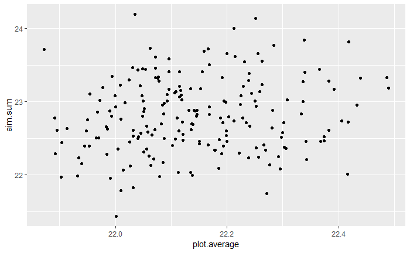

```r
base_graph <- ggplot(data=ht_data, aes(x=plot.average, y=aim.sum)) + geom_point()
base_graph # Need to call this object to display it.
```

OK, that’s a great start, but the two different simulations are all in there together. Let’s try separating them by color by adding a color aesthetic.

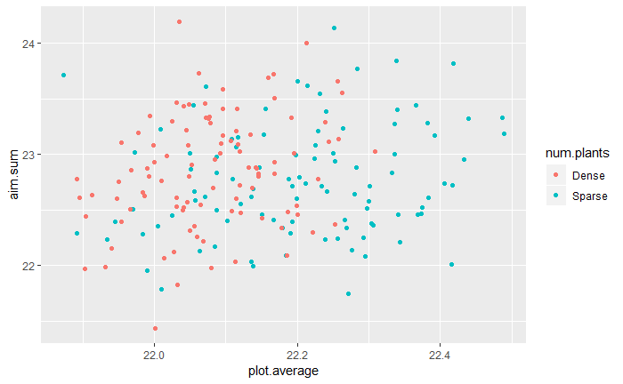

```r
base_graph <- ggplot(data=ht_data, aes(x=plot.average, y=aim.sum)) + geom_point(aes(color=num.plants))
base_graph # Need to call this object to display it.
```

Yuck. That doesn’t look good at all. What about if we put the two different simulations on adjacent plots? We can use **facets** for that. ggplot has two faceting options: **facet_wrap** for automatically wraping the individual graphs into your available space and **facet_grid** for creating a defined matrix of graphs.

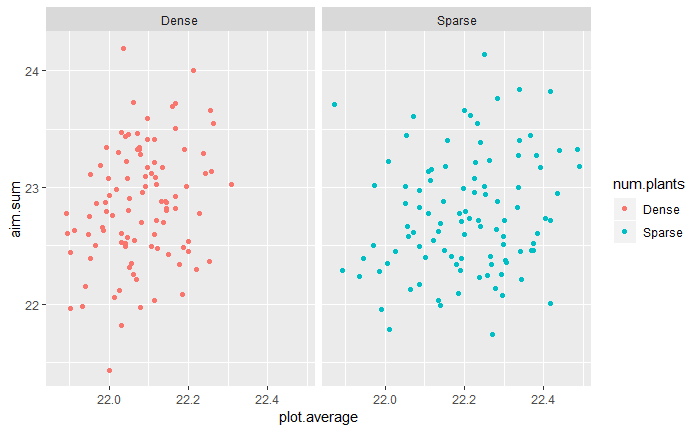

```r
faceted_graphs <- base_graph + facet_wrap(facets=~num.plants)
faceted_graphs
```

```r
## Notice two things here:
##  1. I didn't need to recreate the entire graph. I just called the base_graph object and added to it.
##  2. For facet_wrap I had to tell it which variable to facet by and I had to use the ~ symbol to do it. The ~ symbol in R is used to denote a formula.
```

That looks better. Now let’s add a 1:1 line and regression trend line to the graphs. Notice how I’m just adding to the existing graph here rather than creating it all over again.

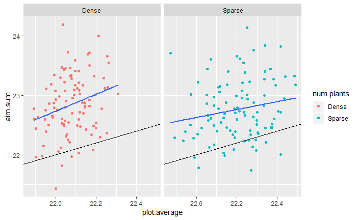

```r
trend_lines <- faceted_graphs + stat_smooth(method="lm",se=FALSE) +
                geom_abline(slope=1,intercept=0)
trend_lines
```

Not bad. But what about presenting the data as boxplots?

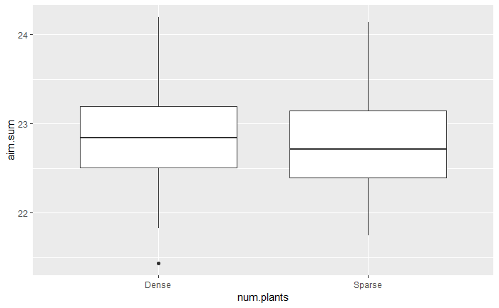

```r
boxplot_graphs <- ggplot(data=ht_data, aes(x=num.plants, y=aim.sum))+geom_boxplot()
boxplot_graphs # Note this is just for one method. If we want/need to have the methods on the X axis (or as facets), we'll need to gather the data.
```

Hmm… That’s not doing anything for me. What about if we looked at boxplots of how far the simulations are from actual? That’s easy to do with ggplot!

Also, those boxplots are pretty fat. What about making them narrower?

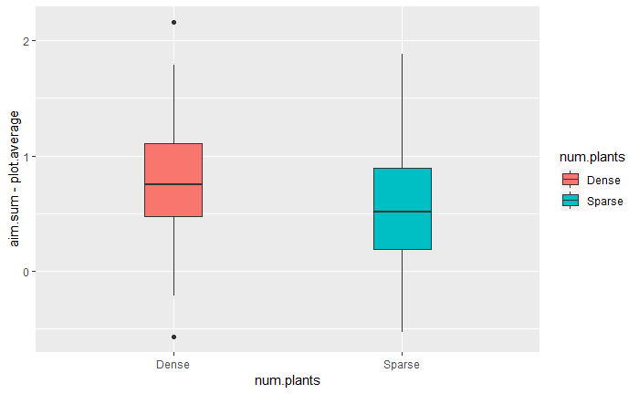

```r
boxplot_graphs <- ggplot(data=ht_data,
                         aes(x=num.plants,
                             y=aim.sum-plot.average, # Note the math in the aesthetic.
                             fill=num.plants))+  # Add some color
                  geom_boxplot(width=0.25)
boxplot_graphs
```

OK, that’s sort of alright, but let’s do some prettying up of this graph.

First, let’s get some decent axis labels and a title.

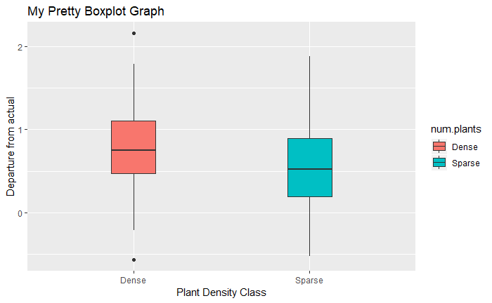

```r
pretty_graphs <- boxplot_graphs +
  labs(title = "My Pretty Boxplot Graph", x="Plant Density Class", y="Departure from actual")
pretty_graphs
```

Better. How about adding some color?

First, a note: in ggplot, **color** refers to the line or point color. **fill** refers to the color to fill a polygon. notice in the graph above that the polygons are filled, but the outline is black because we just specified the fill.

[figure not shown]

OK. Let’s now save our amazing grap to a high-res TIFF file using **ggsave()**.

```r
ggsave("~/GitHub/REM504-DataScience/Practice_Datasets/my_amazing_graph.tif",color_graphs,device = "tiff",width=8,height=6,units="in",dpi=300)
```